# House Price EDA

###### by Urvang Patel

```r
library(ggplot2)
library(gridExtra)
library(GGally)
```

The data set that I am using here is a data of prices of the house in a area. The data set contains some necessary variables that a person looks before buying a house.I will try to explore this data set and try to understand what all factors affects mainly in deciding the price of a house, using plots and statistics.

## Basic Statistics of Data

First load the file using the read.csv function, and find the basic statistics of all the attributes such as mean, median, mode, etc.

```
## 'data.frame':    21613 obs. of  21 variables:
##  $ id           : num  7.13e+09 6.41e+09 5.63e+09 2.49e+09 1.95e+09 ...
##  $ date         : Factor w/ 372 levels "20140502T000000",..: 165 221 291 221 284 11 57 252 340 306 ...
##  $ price        : num  221900 538000 180000 604000 510000 ...
##  $ bedrooms     : int  3 3 2 4 3 4 3 3 3 3 ...
##  $ bathrooms    : num  1 2.25 1 3 2 4.5 2.25 1.5 1 2.5 ...
##  $ sqft_living  : int  1180 2570 770 1960 1680 5420 1715 1060 1780 1890 ...
##  $ sqft_lot     : int  5650 7242 10000 5000 8080 101930 6819 9711 7470 6560 ...
##  $ floors       : num  1 2 1 1 1 1 2 1 1 2 ...
##  $ waterfront   : int  0 0 0 0 0 0 0 0 0 0 ...
##  $ view         : int  0 0 0 0 0 0 0 0 0 0 ...
##  $ condition    : int  3 3 3 5 3 3 3 3 3 3 ...
##  $ grade        : int  7 7 6 7 8 11 7 7 7 7 ...
##  $ sqft_above   : int  1180 2170 770 1050 1680 3890 1715 1060 1050 1890 ...
##  $ sqft_basement: int  0 400 0 910 0 1530 0 0 730 0 ...
##  $ yr_built     : int  1955 1951 1933 1965 1987 2001 1995 1963 1960 2003 ...
##  $ yr_renovated : int  0 1991 0 0 0 0 0 0 0 0 ...
##  $ zipcode      : int  98178 98125 98028 98136 98074 98053 98003 98198 98146 98038 ...
##  $ lat          : num  47.5 47.7 47.7 47.5 47.6 ...
##  $ long         : num  -122 -122 -122 -122 -122 ...
##  $ sqft_living15: int  1340 1690 2720 1360 1800 4760 2238 1650 1780 2390 ...
##  $ sqft_lot15   : int  5650 7639 8062 5000 7503 101930 6819 9711 8113 7570 ...
```

There are 14 int, 6 num and 1 factor data types in the data set.

```
##        id                         date           price
##  Min.   :1.000e+06   20140623T000000:  142   Min.   :  75000
##  1st Qu.:2.123e+09   20140625T000000:  131   1st Qu.: 321950
##  Median :3.905e+09   20140626T000000:  131   Median : 450000
##  Mean   :4.580e+09   20140708T000000:  127   Mean   : 540088
##  3rd Qu.:7.309e+09   20150427T000000:  126   3rd Qu.: 645000
##  Max.   :9.900e+09   20150325T000000:  123   Max.   :7700000
##                      (Other)        :20833
##     bedrooms        bathrooms      sqft_living       sqft_lot
##  Min.   : 0.000   Min.   :0.000   Min.   :  290   Min.   :    520
##  1st Qu.: 3.000   1st Qu.:1.750   1st Qu.: 1427   1st Qu.:   5040
##  Median : 3.000   Median :2.250   Median : 1910   Median :   7618
##  Mean   : 3.371   Mean   :2.115   Mean   : 2080   Mean   :  15107
##  3rd Qu.: 4.000   3rd Qu.:2.500   3rd Qu.: 2550   3rd Qu.:  10688
##  Max.   :33.000   Max.   :8.000   Max.   :13540   Max.   :1651359
##
##      floors        waterfront            view          condition
##  Min.   :1.000   Min.   :0.000000   Min.   :0.0000   Min.   :1.000
##  1st Qu.:1.000   1st Qu.:0.000000   1st Qu.:0.0000   1st Qu.:3.000
##  Median :1.500   Median :0.000000   Median :0.0000   Median :3.000
##  Mean   :1.494   Mean   :0.007542   Mean   :0.2343   Mean   :3.409
##  3rd Qu.:2.000   3rd Qu.:0.000000   3rd Qu.:0.0000   3rd Qu.:4.000
##  Max.   :3.500   Max.   :1.000000   Max.   :4.0000   Max.   :5.000
##
##      grade          sqft_above   sqft_basement       yr_built
##  Min.   : 1.000   Min.   : 290   Min.   :   0.0   Min.   :1900
##  1st Qu.: 7.000   1st Qu.:1190   1st Qu.:   0.0   1st Qu.:1951
##  Median : 7.000   Median :1560   Median :   0.0   Median :1975
##  Mean   : 7.657   Mean   :1788   Mean   : 291.5   Mean   :1971
##  3rd Qu.: 8.000   3rd Qu.:2210   3rd Qu.: 560.0   3rd Qu.:1997
##  Max.   :13.000   Max.   :9410   Max.   :4820.0   Max.   :2015
##
##   yr_renovated       zipcode           lat             long
##  Min.   :   0.0   Min.   :98001   Min.   :47.16   Min.   :-122.5
##  1st Qu.:   0.0   1st Qu.:98033   1st Qu.:47.47   1st Qu.:-122.3
##  Median :   0.0   Median :98065   Median :47.57   Median :-122.2
##  Mean   :  84.4   Mean   :98078   Mean   :47.56   Mean   :-122.2
##  3rd Qu.:   0.0   3rd Qu.:98118   3rd Qu.:47.68   3rd Qu.:-122.1
##  Max.   :2015.0   Max.   :98199   Max.   :47.78   Max.   :-121.3
##
##  sqft_living15    sqft_lot15
##  Min.   : 399   Min.   :   651
##  1st Qu.:1490   1st Qu.:  5100
##  Median :1840   Median :  7620
##  Mean   :1987   Mean   : 12768
##  3rd Qu.:2360   3rd Qu.: 10083
##  Max.   :6210   Max.   :871200
##
```

Observations from the summary are:

*There might be a error in bedrooms attribut since max numbers shown is 33.

*Less than 25% of the houses were renovated.

*Less than 25% houses have a view greater than 1.

## Univariate Analysis

#### Price Histogram

The very first question that comes to mind is that, how is the price variable distributed? TO answer this question I will take the help of ggplot2 library and plot a histogram of the price variable. THe plot is shown below.

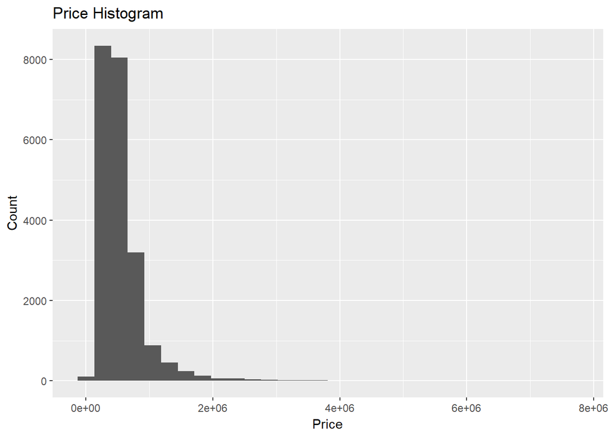

The histogram of the price variable is not giving much information. We can see that all the data is accumulate towards the lower end of the price axis, but the axis is streched to a higher price value. The reason behind this is that there are outliars present in the data. The outliars drags the mean and makes it higher than the orignal. Due to the outliars the houses with lower prices are not visible clearly.

There is a possiblity of many outliars present in the data. As no information is visible on the axis. TO observe the price distribution try limiting the maximum value of the price axis. Doing that might give more information.

The histogeam of price variable with axis limited to 3 million is shown below.

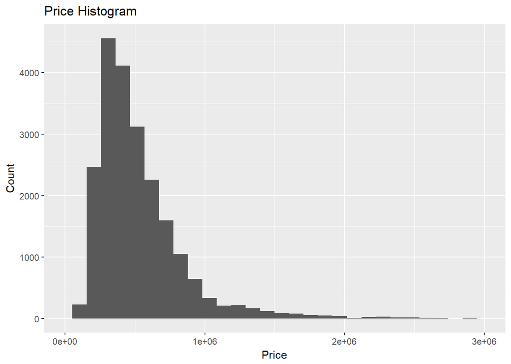

The histogram I got is a skewed distribution meaning that the mean value is greather than the median value. It can be seen that majority of the houses cost below 1 million.

Still there is a long tail at the right end, so it would be a better option to take log transform of the data.

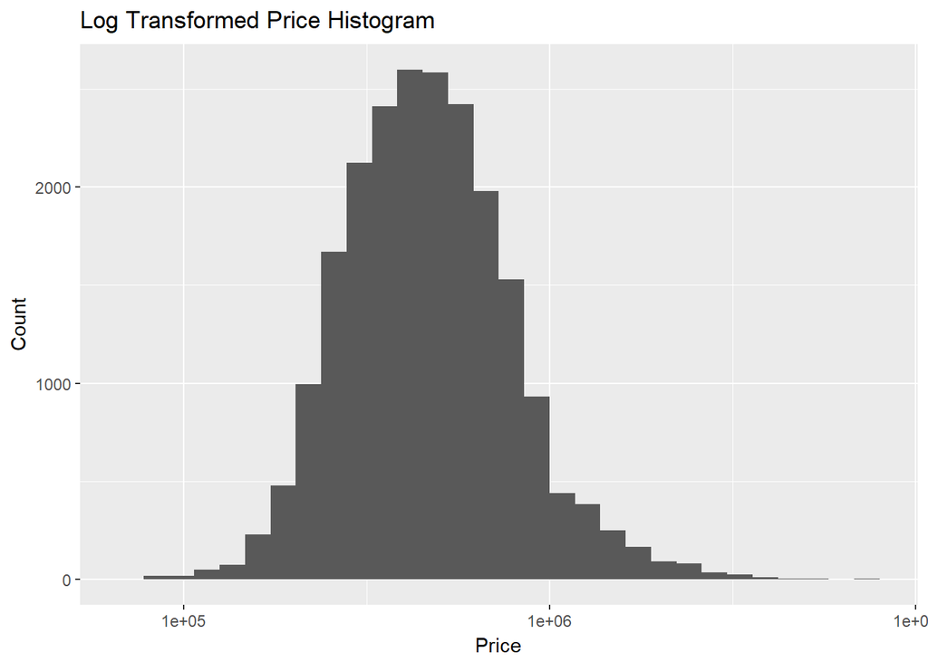

As expected we get a normal distribution after the log transform of the price data.

#### Other Attributes

Now, the next question that comes is how are some other continous variables distributed. I will plot the histogram for some variables and also limit the axis to observe the plot properly.

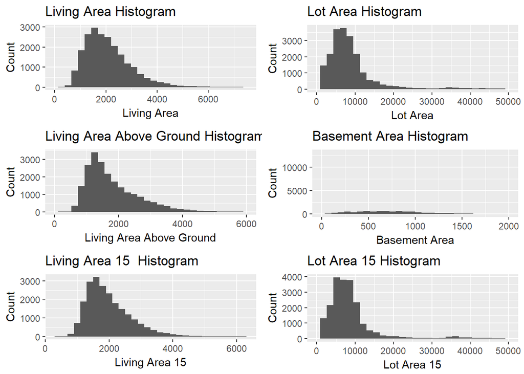

All the plots above are skwed and have a long tail suggesting that there are numerous number of outliars in the data set.

## Bivariate Analysis

#### Really 33 rooms?

The very first thing I want to check is if the house whith 33 bedrooms is a wrong input or outliar. I will check this by plotting living area against bedrooms. The expected living of the house with 33 bedrooms should be greter than every other house since it will require more area.

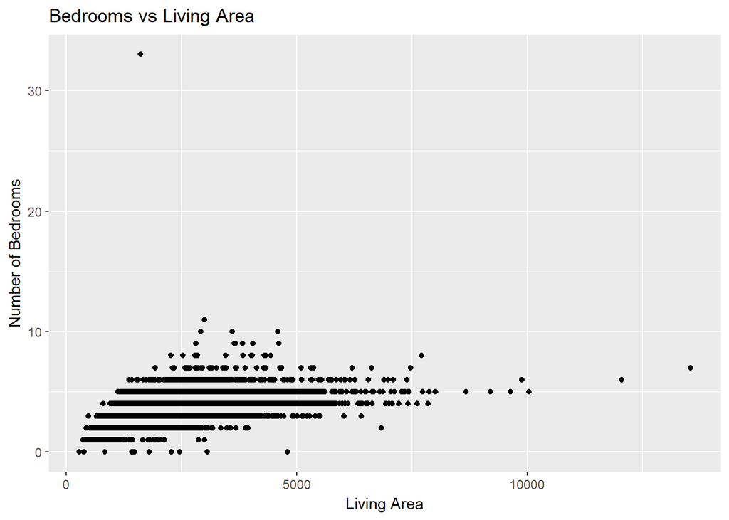

As it can be seen in the above scatter plot that the house with 33 rooms has a living are less than 2500 which cannot happen. So the entry of house with 33 rooms is not correct.

#### Scatter plot Matrix

Next I wil try plotting a scatter plot matrix which helps in plotting all the attributes against the price attribute in single figure. Also some other correlations will be observed as every attribute is plotted against one other.

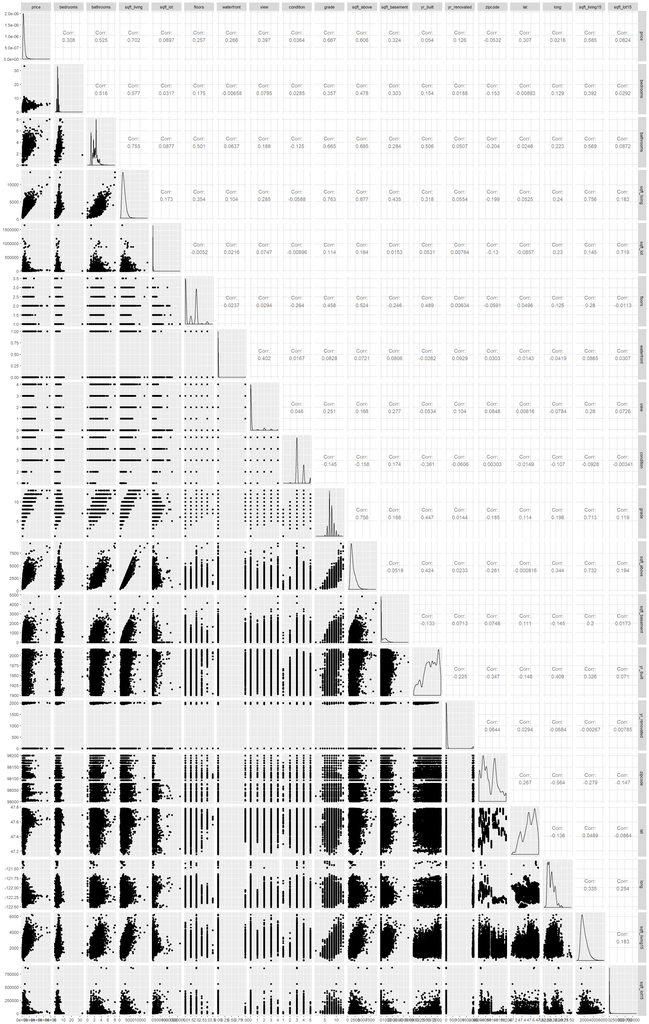

Observations from the above matrix are:

*It can also be seen that as the grade is increasing the price of the houses is also increasing.

*Some other expected correlations of attributes can also be observed like +bedroom vs bathrooms. +sqft_living vs bedroom and bathroom. +sqft_living vs grade. +And other few such relations.

*Also there are many outliars present.

Further investigations from the above plot:

*I wish to check sqft_lot and lot15 attributes against price as the graphs above are not very clear.

*The correlation coeff shows that there is a relation in price against view, lets further check it out.

#### Checking Lot area attribute

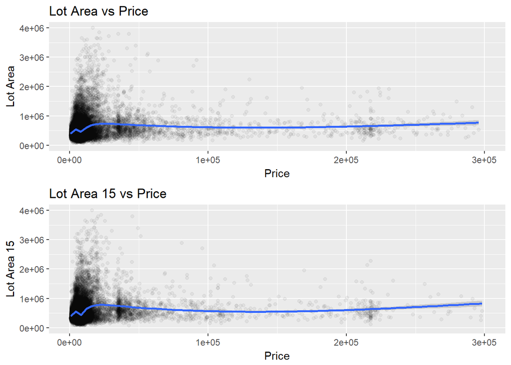

I have removed many higher values from the plot, considering them as outliars. Doing this helped me observe the graph closely. We can see that even thought the lot size is increasing the price is not changing, it remains low, and for some lower value of lot price is high. From the above plots it can be said that both the lot and lot15 attribute does not seem to be correlated strongly to the price attribute.

#### Checking view attribute against price

Next, I will check the correlation betwwn view and price attribute.

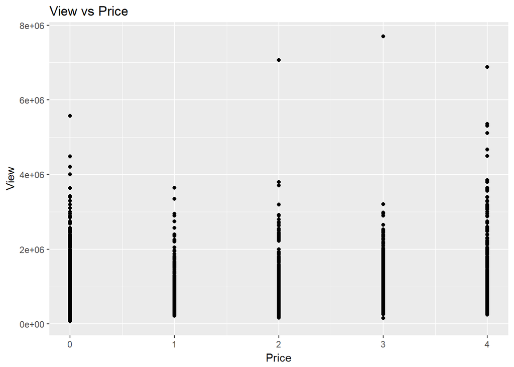

The scatter plot here does not show much correlation, let’s try some other kind of plot.

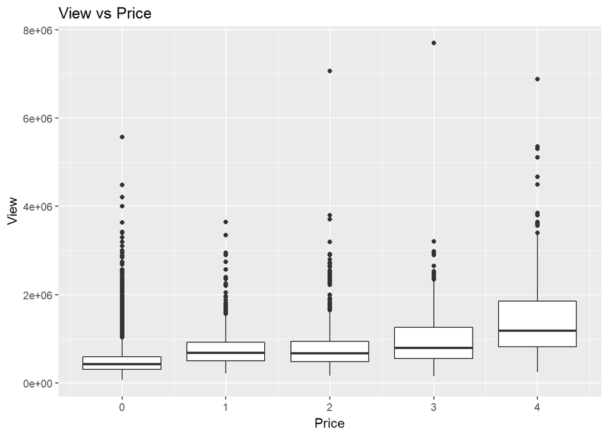

here now box plot revels the correlation betwwen price and view attribute. It can be seen that as the view rating increases the price increases.

#### Year built and renovated

Many houses are not renovated and some few are only revovated. I created a new attribute named renovated containing value 0 for no renovation and value 1 if renovation is done.

I also created groups of the yr_built attribute into catagories.

```
##  [1] "id"                "date"              "price"
##  [4] "bedrooms"          "bathrooms"         "sqft_living"
##  [7] "sqft_lot"          "floors"            "waterfront"
## [10] "view"              "condition"         "grade"
## [13] "sqft_above"        "sqft_basement"     "yr_built"
## [16] "yr_renovated"      "zipcode"           "lat"
## [19] "long"              "sqft_living15"     "sqft_lot15"
## [22] "renovated"         "year_built_groups"
```

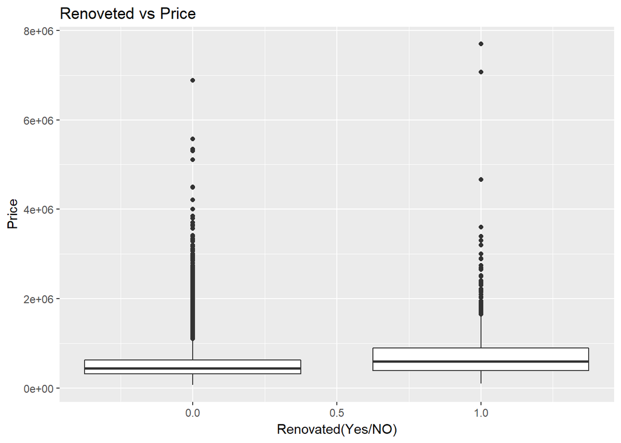

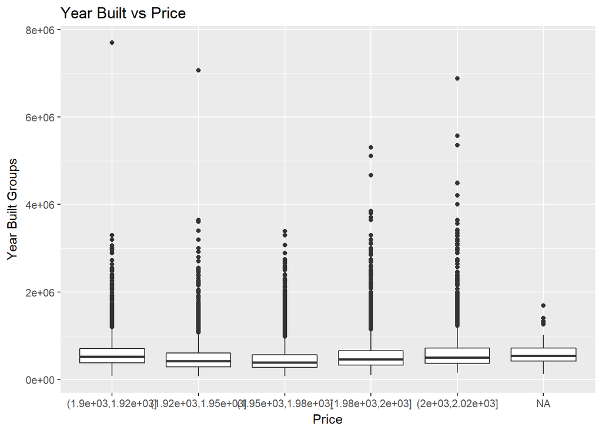

No strong relation with year built was found.

## Multivariate Analysis

#### Dose year built affect other attributes?

Let’s check how year built is affecting all the other attributes in the data set.

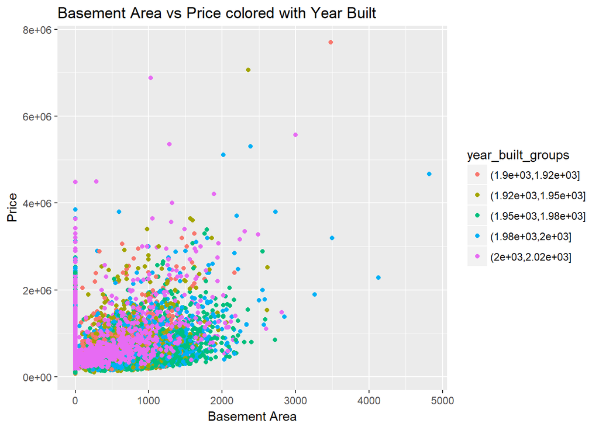

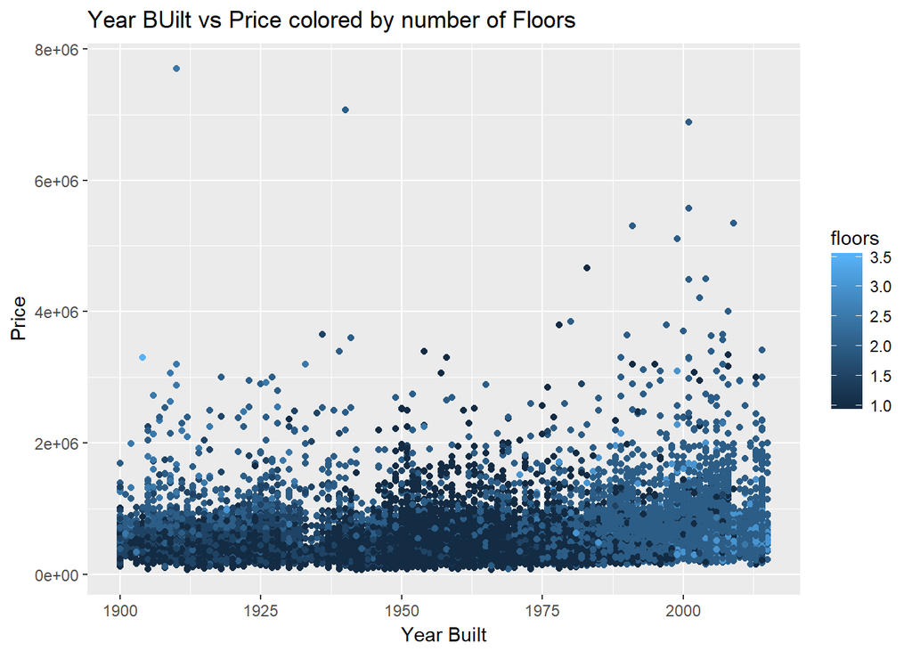

We can see that newer houses have miltiple floors while older houses didn’t have many floors.

#### Grade or Condition

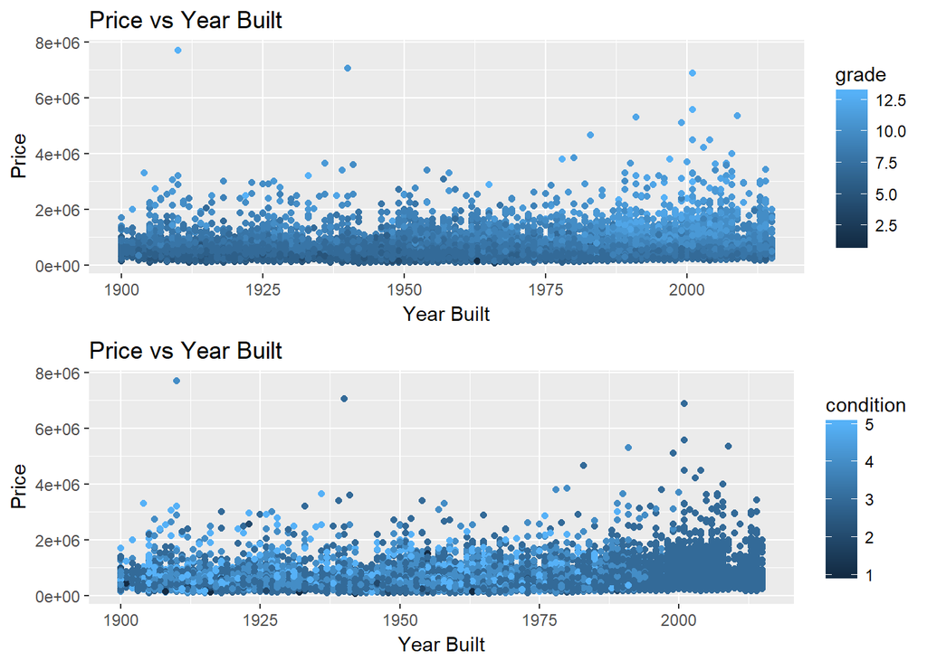

It seems that grade and conditions are same. Lets further check this out.

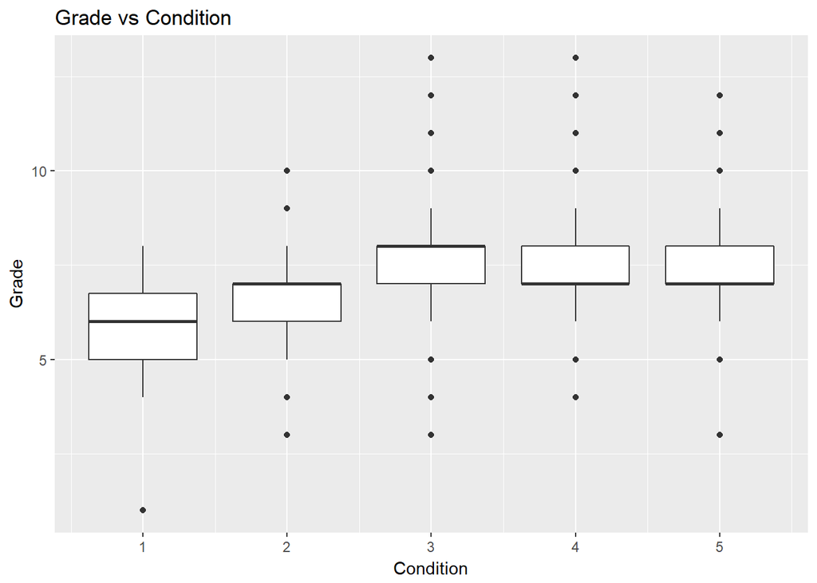

```r
ggplot(aes(condition,grade,group=condition),data = house)+geom_boxplot()+
  labs(title="Grade vs Condition",
        x ="Condition", y = "Grade")
```

From the above plot we can see that at first grade increses with increase in condition but later there is no perticular trend. They both cannot be considered same.

#### Longitude and Latitude

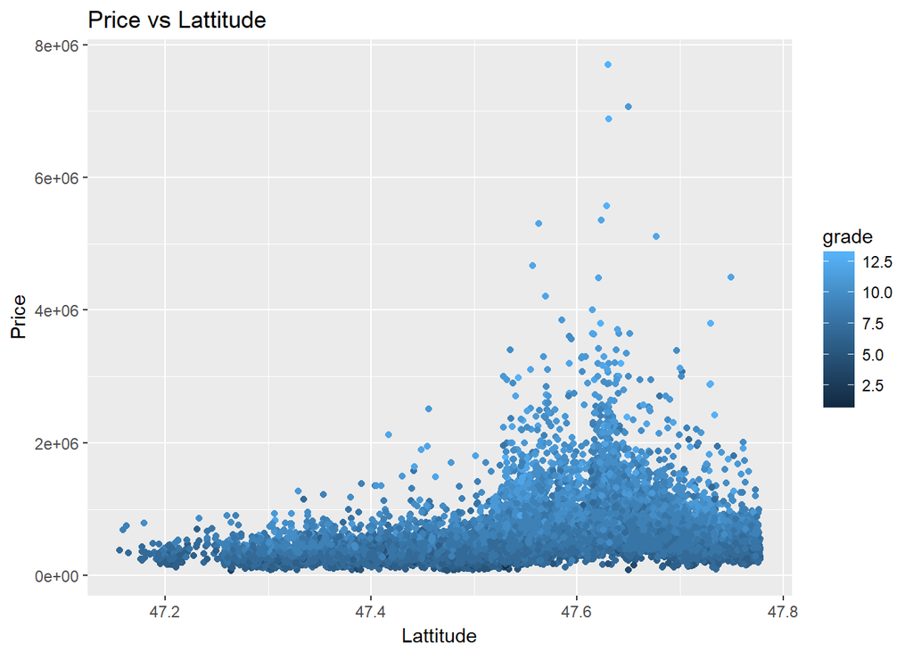

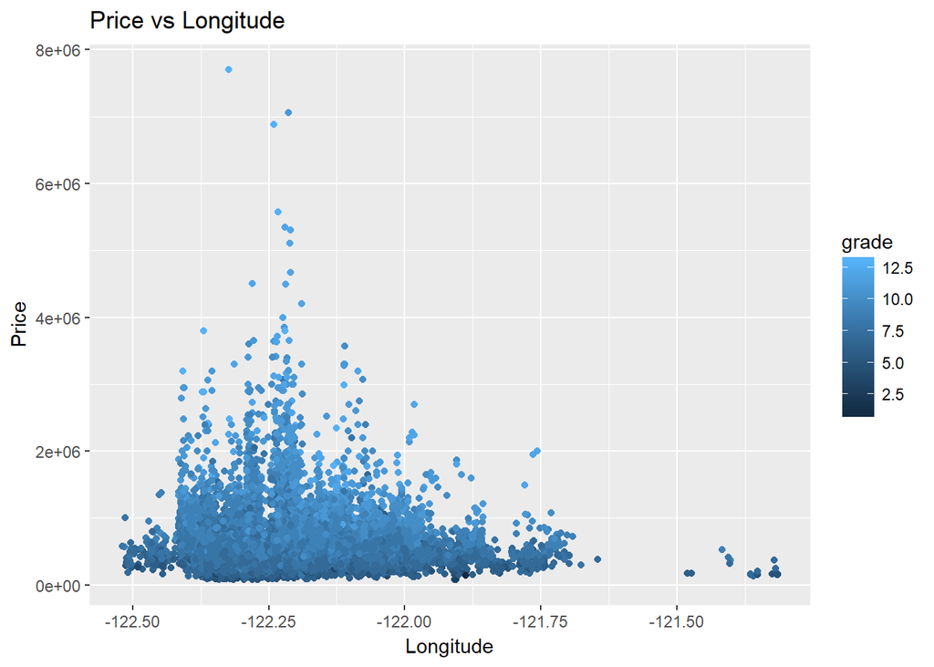

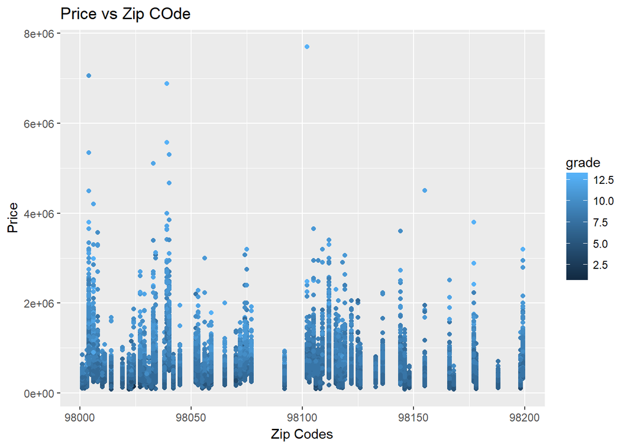

These plots just show that higher prizes of houses on some longitude, latitude and zip codes have higher grades.

## Conclusion

From the above process of explonatory data analysis it can be said taht the price attribute is highly dependent on various other attributes.

Attributes such as lot area and year built are not related to the price of the house.

The next step after this is to perform hypothesis testing and then finally creating a predictive model.